# DC Exercises: Chapter 7 Solutions

Written by Emily Strong

6/15/2020

# Exercise 7.1

The operations listed involve the following corresponding functions:

1. **Reduction**; takes the values of a numeric variable and returns a scalar.
2. **Neither**; does not return a value for each case, and does not return a scalar.
3. **Reduction**; see section 7.3 in the textbook.
4. If we are given a set of years and want to determine whether or not each one is a leap year, then this involves a **Transformation** function. If we are given only one year and want to determine whether or not it is a leap year, then this inolves **neither** type of function, since the input is not a variable.
5. If we are given a set of dates and want to determine whether or not each one is a legal holiday, then this involves a **Transformation** function. If we are given only one date and want to determine whether or not it is a legal holiday, then this inolves **neither** type of function, since the input is not a variable.
6. **Reduction**; takes the values of a numeric variable and returns a scalar.
7. If we are given a set of dates and want to determine the day of the week for each one, then this involves a **Transformation** function. If we are given only one date and want to determine what day of the week it is, then this inolves **neither** type of function, since the input is not a variable.
8. **Reduction**; takes a set of dates and returns a scalar (the range, in this case).

# Exercise 7.3

## Part (a)

```r
library(DataComputing)
data("Minneapolis2013")
Minneapolis2013 %>%
  summarise(count=n())
```

| count |
| --- |
| 80101 |

There are 80,101 cases in the `Minneapolis2013` data table.

## Part (b)

```r
Minneapolis2013 %>%
  group_by(Second) %>%
  summarise(Ballots=n()) %>%
  arrange(desc(Ballots))
```

| Second | Ballots |
| --- | --- |
| BETSY HODGES | 14399 |
| DON SAMUELS | 14170 |
| MARK ANDREW | 12757 |
| undervote | 10598 |
| JACKIE CHERRYHOMES | 6470 |
| BOB FINE | 3751 |
| CAM WINTON | 3751 |

The top five candidates in the `Second` vote selections, in order, were: Betsy Hodges, Don Samuels, Mark Andrew, undervote and Jackie Cherryhomes.

## Part (c)

```r
Minneapolis2013 %>%
  group_by(First) %>%
  summarise(Ballots=sum(ifelse(First=="undervote", yes=1, no=0))) %>%
  arrange(desc(Ballots))
```

| First | Ballots |
| --- | --- |
| undervote | 834 |
| ABDUL M RAHAMAN “THE ROCK” | 0 |
| ALICIA K. BENNETT | 0 |

834 ballots were marked “undervote” in `First` choice selections.

```r
Minneapolis2013 %>%
  group_by(Second) %>%
  summarise(Ballots=sum(ifelse(Second=="undervote", yes=1, no=0))) %>%
  arrange(desc(Ballots))
```

| Second | Ballots |
| --- | --- |
| undervote | 10598 |
| ABDUL M RAHAMAN “THE ROCK” | 0 |
| ALICIA K. BENNETT | 0 |

10,598 ballots were marked “undervote” in `Second` choice selections.

```r
Minneapolis2013 %>%
  group_by(Third) %>%
  summarise(Ballots=sum(ifelse(Third=="undervote", yes=1, no=0))) %>%
  arrange(desc(Ballots))
```

| Third | Ballots |
| --- | --- |
| undervote | 19210 |
| ABDUL M RAHAMAN “THE ROCK” | 0 |
| ALICIA K. BENNETT | 0 |

19,210 ballots were marked “undervote” in `Third` choice selections.

## OR

```r
Minneapolis2013 %>%
  group_by(First) %>%
  summarise(count=n()) %>%
  filter(First=="undervote")
Minneapolis2013 %>%
  group_by(Second) %>%
  summarise(count=n()) %>%
  filter(Second=="undervote")
Minneapolis2013 %>%
  group_by(Third) %>%
  summarise(count=n()) %>%
  filter(Third=="undervote")
```

| First | count |
| --- | --- |
| undervote | 834 |

| Second | count |
| --- | --- |
| undervote | 10598 |

| Third | count |
| --- | --- |
| undervote | 19210 |

## Part (d)

```r
Minneapolis2013 %>%
  group_by(First, Second) %>%
  summarise(Ballots=sum(n())) %>%
  arrange(desc(Ballots))
```

| First | Second | Ballots |
| --- | --- | --- |
| BETSY HODGES | MARK ANDREW | 8787 |
| BETSY HODGES | DON SAMUELS | 8743 |
| MARK ANDREW | BETSY HODGES | 6970 |
| MARK ANDREW | undervote | 3889 |
| DON SAMUELS | BETSY HODGES | 3346 |

The top three combinations of `First` and `Second` vote selections, in order, were:

1. Betsy Hodges (First) and Mark Andrews (Second): 8,787 ballots.
2. Betsy Hodges (First) and Don Samuels (Second): 8,743 ballots.
3. Mark Andrew (First) and Betsy Hodges (Second): 6,970 ballots.

## Part (e)

```r
Minneapolis2013 %>%
  group_by(Precinct) %>%
  summarise(Ballots=sum(n())) %>%
  arrange(desc(Ballots))
```

| Precinct | Ballots |
| --- | --- |
| P-06 | 9711 |
| P-02 | 9551 |
| P-08 | 9430 |

`Precinct` P-06 had the highest number of ballots cast, with 9,711 in total.

# Exercise 7.6

## Part (a)

In the following scatterplot, each glyph (i.e. each dot) represents one level of the `State` variable in the `ZipGeography` data. The horizontal position of a glyph represents the total land area for a given state, and its vertical position represents the total population in that state.

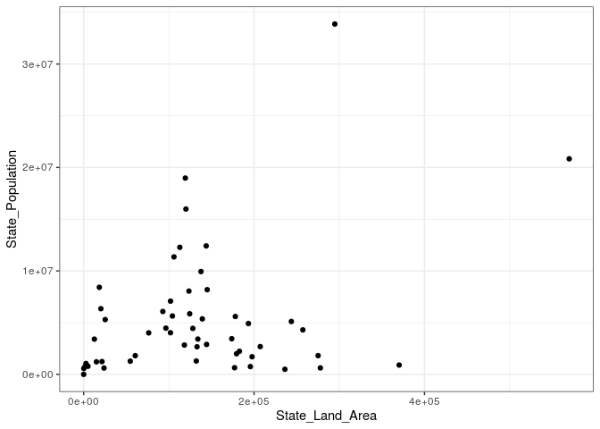

```r
data("ZipGeography")
ZipGeography %>%
  group_by(State) %>%
  summarise(State_Land_Area=sum(LandArea, na.rm=TRUE),
            State_Population=sum(Population, na.rm=TRUE)) %>%
  ggplot(aes(y=State_Population, x=State_Land_Area)) +
  geom_point() +
  theme_bw()
```

## Part (b)

The following graph is a choropleth map showing the population of each state. Each glyph is a state on the map. Lighter-colored states have higher populations than darker-colored states.

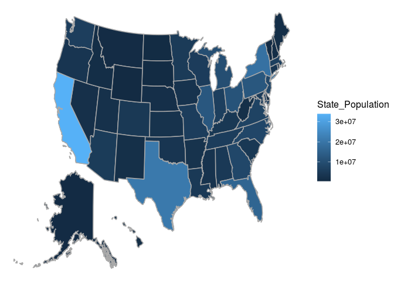

```r
geoSummary <- ZipGeography %>%
  group_by(State) %>%
  summarise(State_Population = sum(Population, na.rm = TRUE))
USMap(data=geoSummary, key = "State", fill = State_Population)
```

## Part (c)

The following graph is a choropleth map showing the population per unit area of each state. Each glyph is a state on the map. Lighter-colored states have higher population-to-area ratios than darker-colored states.

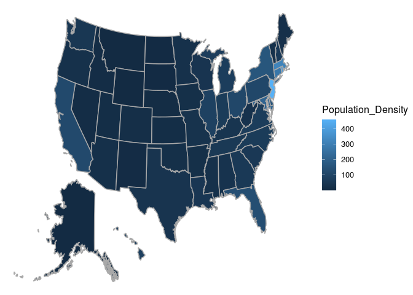

```r
geoSummary = ZipGeography %>%
  group_by(State) %>%
  summarise(State_Land_Area = sum(LandArea, na.rm = TRUE),
            State_Population = sum(Population, na.rm = TRUE))
geoSummary = na.omit(geoSummary) %>%
  group_by(State) %>%
  summarise(Population_Density = State_Population/State_Land_Area) %>%
  arrange(desc(State))
# removing rows in which "State" is not name of US state, so USMap() will work
geoSummary = geoSummary[-c(which(geoSummary$State==""),
                           which(geoSummary$State=="District of Columbia")),]
USMap(data=geoSummary, key="State", fill=Population_Density)
```

## OR

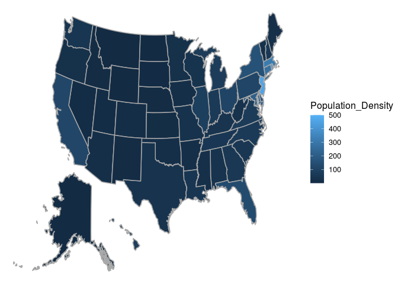

```r
ZipGeography %>%
  group_by(State) %>%
  summarise(State_Land_Area = sum(LandArea, na.rm = TRUE),
            State_Population = sum(Population, na.rm = TRUE)) %>%
  mutate(Population_Density=State_Population/State_Land_Area) %>%
  mutate(Population_Density=pmin(Population_Density, 500)) %>%
  USMap(key=State, fill=Population_Density)
```

## OR

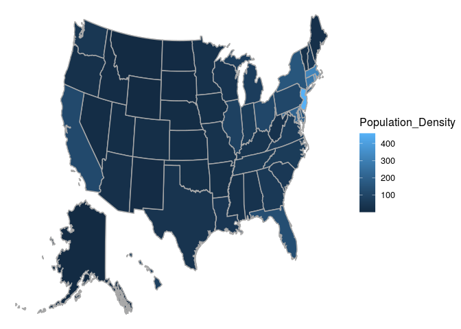

```r
na.omit((ZipGeography)) %>%
  group_by(State) %>%
  summarise(State_Land_Area = sum(LandArea, na.rm = TRUE),
            State_Population = sum(Population, na.rm = TRUE),
            Population_Density = sum(State_Population)/sum(State_Land_Area)) %>%
  arrange(desc(Population_Density)) %>%
  filter(State!="District of Columbia" & State!="") %>%
  USMap(key="State", fill=Population_Density)
```

# Exercise 7.7

The variables appearing in the resulting data frame in each case would be:

1. `sex`, `count`, `meanAge`
2. `Diagnosis`, `count`, `meanAge`
3. `sex`, `Diagnosis`, `count`, `meanAge`
4. `age`, `Diagnosis`, `count`, `meanAge`
5. `age`, `count`, `meanAge`